# Time Series Modeling - A Brief Overview

September 25, 2017

## Introduction

- When a variable is measure sequentially in time over or at a fixed interval, known as the *sampling interval*, the resulting data form a *time series*.

Key Features:

- Trends and Seasonal Variations
- Observations close together in time tend to be correlated or *serially dependent*

## Setup

Packages to install if you don’t already have them:

- `lubridate`
- `xts`
- `zoo`
- `devtools`

```r
rm(list = ls()) # clear environment
```

## Date & Time Object Basics

```r
Sys.Date()
```

```
[1] "2017-09-27"
```

```r
Sys.time()
```

```
[1] "2017-09-27 09:10:00 EDT"
```

```r
str(Sys.time())
```

```
 POSIXct[1:1], format: "2017-09-27 09:10:00"
```

```r
ct <- as.POSIXct(Sys.time())
lt <- as.POSIXlt(Sys.time())
ct; lt
```

```
[1] "2017-09-27 09:10:00 EDT"
[1] "2017-09-27 09:10:00 EDT"
```

```r
str(ct); str(lt)
```

```
 POSIXct[1:1], format: "2017-09-27 09:10:00"
 POSIXlt[1:1], format: "2017-09-27 09:10:00"
```

- `POSIXct` is a numeric object
- `POSIXlt` is a list object

```r
mode(lt); mode(ct)
```

```
[1] "list"
[1] "numeric"
```

```r
# use unlist to flatten to vector
names(unlist(lt))
```

```
 [1] "sec"    "min"    "hour"   "mday"   "mon"    "year"   "wday"   "yday"
 [9] "isdst"  "zone"   "gmtoff"
```

Class “POSIXct” represents the (signed) number of seconds since the beginning of 1970 (UTC).

```r
as.numeric(ct)
```

```
[1] 1506517801
```

### Converting text to Date-time

- `strptime`

```r
str("2017-01-01")
```

```
 chr "2017-01-01"
```

```r
as.Date("2017-01-01")
```

```
[1] "2017-01-01"
```

```r
str(as.Date("2017-01-01"))
```

```
 Date[1:1], format: "2017-01-01"
```

```r
20170101
```

```
[1] 20170101
```

```r
str(20170101)
```

```
 num 20170101
```

```r
# as.Date(20170101) this would not work
```

```r
# as.Date(20170101, format = "%Y%m%d") would not work
as.Date(as.character(20170101), format = "%Y%m%d")
```

```
[1] "2017-01-01"
```

```r
as.Date("20170101", format = "%Y%m%d")
```

```
[1] "2017-01-01"
```

- `?strptime` is your friend here with widely implemented conversion specifications in the Details section. [C spec resource](http://pubs.opengroup.org/onlinepubs/009695399/functions/strftime.html)

### Time Periods

- `seq` has some time-based options.

```r
seq(from = as.Date("2017-01-01"), to = as.Date("2017-01-31"), by = "days")
```

```
 [1] "2017-01-01" "2017-01-02" "2017-01-03" "2017-01-04" "2017-01-05"
 [6] "2017-01-06" "2017-01-07" "2017-01-08" "2017-01-09" "2017-01-10"
[11] "2017-01-11" "2017-01-12" "2017-01-13" "2017-01-14" "2017-01-15"
[16] "2017-01-16" "2017-01-17" "2017-01-18" "2017-01-19" "2017-01-20"
[21] "2017-01-21" "2017-01-22" "2017-01-23" "2017-01-24" "2017-01-25"
[26] "2017-01-26" "2017-01-27" "2017-01-28" "2017-01-29" "2017-01-30"
[31] "2017-01-31"
```

```r
my.seq <- seq(from = as.Date("2017-01-01"), to = as.Date("2017-06-30"), by = "months")
my.seq
```

```
[1] "2017-01-01" "2017-02-01" "2017-03-01" "2017-04-01" "2017-05-01" "2017-06-01"
```

```r
str(my.seq)
```

```
 Date[1:6], format: "2017-01-01" "2017-02-01" "2017-03-01" "2017-04-01" "2017-05-01" ...
```

```r
is.ts(my.seq)
```

```
[1] FALSE
```

### Time Series Objects

```r
ts(1:10)
```

```
Time Series:
Start = 1
End = 10
Frequency = 1
 [1]  1  2  3  4  5  6  7  8  9 10
```

```r
# monthly
ts(1:10, start = c(2017, 1), frequency = 12)
```

```
     Jan Feb Mar Apr May Jun Jul Aug Sep Oct
2017   1   2   3   4   5   6   7   8   9  10
```

```r
# quarterly
ts(1:10, start = c(2017, 1), frequency = 4)
```

```
     Qtr1 Qtr2 Qtr3 Qtr4
2017    1    2    3    4
2018    5    6    7    8
2019    9   10
```

```r
# annual
ts(1:10, start = c(2017, 1), frequency = 1)
```

```
Time Series:
Start = 2017
End = 2026
Frequency = 1
 [1]  1  2  3  4  5  6  7  8  9 10
```

Only works with certain frequencies…

```r
ts(1:10, start = c(2017, 1), frequency = 365)
```

```
Time Series:
Start = c(2017, 1)
End = c(2017, 10)
Frequency = 365
 [1]  1  2  3  4  5  6  7  8  9 10
```

```r
my.ts <- ts(1:12, start = c(2017, 1), frequency = 12)
str(my.ts)
```

```
 Time-Series [1:12] from 2017 to 2018: 1 2 3 4 5 6 7 8 9 10 ...
```

```r
attributes(my.ts)
```

```
$tsp
[1] 2017.000 2017.917   12.000

$class
[1] "ts"
```

#### Other Useful Packages

**`zoo`**

Particularly aimed at irregular time series.

```r
zoo::as.zoo(my.ts)
```

```
Jan 2017 Feb 2017 Mar 2017 Apr 2017 May 2017 Jun 2017 Jul 2017 Aug 2017 Sep 2017
       1        2        3        4        5        6        7        8        9
Oct 2017 Nov 2017 Dec 2017
      10       11       12
```

**`xts`**

eXtensible Time Series. Uniform handling of time-based data. Extends `zoo` and reduces compatability issues.

```r
xts::as.xts(my.ts)
```

```
         [,1]
Jan 2017    1
Feb 2017    2
Mar 2017    3
Apr 2017    4
May 2017    5
Jun 2017    6
Jul 2017    7
Aug 2017    8
Sep 2017    9
Oct 2017   10
Nov 2017   11
Dec 2017   12
```

**`lubridate`**

R Studio group package which like many of their offerings makes things very simple to understand. Especially good for extracting time-based components and performing math. Concepts of duration, interval, and period are well worth exploring.

In most instances, it is relatively easy to move between `ts`, `zoo`, and `xts` objects.

## Steps in the modeling process

From Max Kuhn:

1. Understand the data
- Visualize!
- If you have more than 1 predictor, could be an indication that you need to pre-process.
2. Build and evaluate a model
- Take a random sample & use the rest to understand model performance
- Residuals are an important source of information!
- Root mean squared error is commonly used to evaluate model performance. SMAPE and AIC are two others I’ve used with some frequency.
3. Mathematically define the relationship
- Be careful not to use the training set to evaluate model performance
- *Resampling* can help to avoid this (k-fold CV, GCV, Monte Carlo CV, Bootstrap)
- Different models can be more susceptible to certain problems
  - Quadratic / log models fitting poorly at the extremes
- Be sure to understand aspects of the model you are using
  - Tuning parameter in MARS model.

#### Data Splitting

- How the training and test sets are determined should relect how the model will be applied
- *extrapolation* vs. *interpolation*

#### Predictor Data

- Feature selection - minimum number of relevant predictors

#### Estimating Performance

- Quantitative assessments (RMSE & AIC)
- Visualize again

#### Evaluating Several Models

- Basis for this general discussion as an introduction
- “No Free Lunch” theorem (Wolpert, 1996)

#### Model Selection

- Some modeling techniques may be excluded (linear, MARS, etc) depending on the application. Choosing *between* models.
- In the MARS, you can alter tuning parameter to get the best result. This is an example of choosing *within* different MARS models.

**Understand the data AND the objective of the model**

#### Data Pre-processing

- **Unsupervised** - the outcome variable is not considered by the pre-processing techniques.
- **Supervised** - the outcome is utilized to pre-process the data.
- **Feature engineering** - how the predictors are encoded, including combinations and transformations. This can be especially important in time series modeling…

```r
require(lubridate)
current_time <- now()
current_time
```

```
[1] "2017-09-27 09:10:01 EDT"
```

This contains a LOT of information!

```r
year(current_time); month(current_time); month.abb[month(current_time)]; day(current_time)
```

```
[1] 2017
[1] 9
[1] "Sep"
[1] 27
```

### Data Transformations for Individual Predictors

#### Centering and Scaling

- The only real downside is a loss of interpretibility
- The benefits are improved model and numerical stability

#### Transformations to Resolve Skewness

A general rule of thumb to consider is that skewed data whose ratio of the highest value to the lowest value is greater than 20 have significant skewness.

Skewness statistic can be used as a diagnostic:

- Symmetric: 0
- Right skewed: > 0
- Left skewed: < 0

$$skewness = {{\sum{(x_i - \bar{x})^3}} \over {(n - 1) v^{3/2}}}$$
$$v = {{\sum(x_i - \bar{x})^2} \over (n - 1)}$$

- log, square root and inverse can all be viable alternatives for eliminating or reducing the skew
- Box-Cox propose a *family* of transformations that are indexed by a parameter $\lambda$

### Data Transformations for Multiple Predictors

##### Transformations to resolve outliers

Great care should be taken not to prematurely remove values - check if there were recording errors.

Be extremely cautious in removing outliers in small sample sizes - they may reveal things that the data collected does not readily show.

- Tree-based classification models are often resistent to outliers.
- If a model is considered to be especially sensitive to outliers, one data transformation that can minimize the problem is the *spatial sign* (Serneels et al. 2006).

$$x^*_ij = {x_ij} \over {\sum^P_j{ = 1^{x^2_ij}}}$$

#### Data Reduction and Feature Extraction

Reduce the data by generating a smaller set of predictors that seek to capture the majority of the information in the original variables. This is often called *signal extraction* or *feature extraction*

$PCA$ is a commonly used data reduction technique. Linear combinations of the predictors, known as principal components (PCs) capture the most possible variance.

#### Dealing with missing values

It is important to know *why* the value is missing. “Informative missingness” shows if the missing data is related to the pattern of missing data.

Missing data should not be confused with *censored* data where the exact value is missing but something is known about its value.

#### Removing Predictors

Potential advantages to removing predictors prior to modeling:

1. Fewer predictors means decreased computational time & complexity
2. If two predictors are highly correlated, this implies they are measuring the same underlying information. Removing one should not compromize the performance of the model and may lead to greater interpretibility.
3. Some models may be crippled by predictors with degenerates distributions. Removing problematic variables can lead to a significant improvement in model performance and interpretability.

#### *Between-Predictor Correlations*

*Collinearity* is the term for a situation where a pair of predictor variables have a substantial correlation with each other.

Using highly correlated predictors in techniques like linear regression can result in highly unstable models, numerical errors, and degraded model performance.

##### Adding Predictors

When a predictor is categorical, such as gender or race, it is common to decompose the predictor into a set of more specific variables.

#### Binning Predictors

- Methods to *avoid*
- Manual binning of continuous data can cause a lot of issues
  - Can cause significant loss of performance in model
  - Loss of precision when predictors are categorized
  - Categorizing variables can lead to a high rate of false positives

## Stationary Models

- Time series will often have well-defined components such as a trend & seasonal pattern
- Residuals will usually be correlated in time even if linear model is well specified.
- Stationary models may well be suited for residual series that contain no obvious trend or seasonal components
- Then combined with original model to improve forecasts.

### Moving average models

#### Correlogram and simulation

Below is a simple autocorrelation function for an MA(*q*) process.

```r
rho <- function(k, beta) {
  q <- length(beta) - 1
  if (k > q) ACF <- 0 else {
    s1 <- 0; s2 <- 0
    for(i in 1:(q-k+1)) s1 <- s1 + beta[i] * beta[i + k]
    for(i in 1:(q+1)) s2 <- s2 + beta[i]^2
    ACF <- s1 / s2
  }
  ACF
}
```

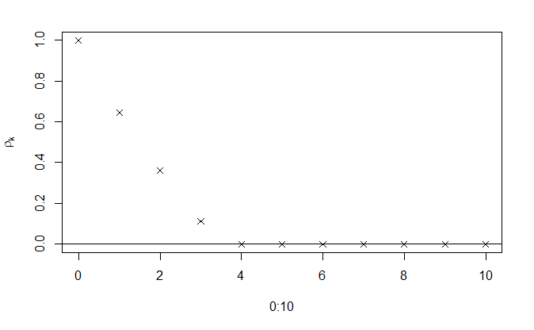

```r
beta <- c(1, 0.7, 0.5, 0.2)
rho.k <- rep(1, 10)
for(k in 1:10) rho.k[k] <- rho(k, beta)
plot(0:10, c(1, rho.k), pch = 4, ylab = expression(rho[k])); abline(0, 0)
```

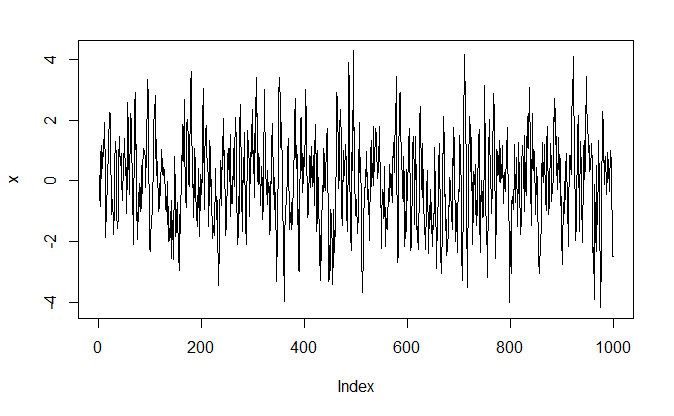

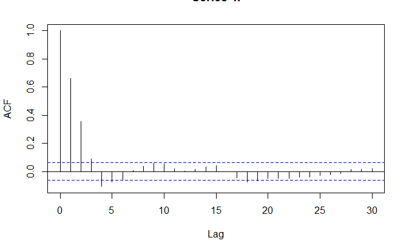

```r
set.seed(1)
b <- c(0.8, 0.6, 0.4)
x <- w <- rnorm(1000)
for (t in 4:1000) {
  for (j in 1:3) x[t] <- x[t] + b[j] * w[t-j]
}
plot(x, type = "l"); acf(x)
```

### Fitted MA models

```r
# ?ar
# ?arima
```

`arima` function does not subtract the mean by default and estimated an intercept term.

```r
x.ma <- arima(x, order = c(0, 0, 3))
```

### Mixed models: The ARMA process

A series ${x_t}$ is an autoregessive process of order $p$, an AR($p$) process, if

$$x_t = \alpha_1 x_{t-1} + \alpha_2 x_{t-2} + ... + \alpha_p x_{t-p} + w_t$$
A useful class of models are obtained when AR and MA terms are added together in a single expression.

Following points should be noted about an ARMA$(p, q)$ process:

### Electricity Production Series

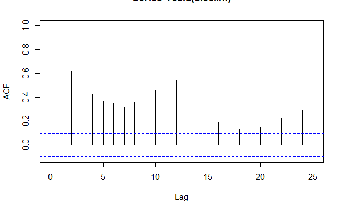

```r
url <- "https://raw.githubusercontent.com/dallascard/Introductory_Time_Series_with_R_datasets/master/cbe.dat"
cbe <- read.table(url, header = T)
elec.ts <- ts(cbe[, 3], start = 1958, freq = 12)
time <- 1:length(elec.ts)
Imth <- cycle(elec.ts)
elec.lm <- lm(log(elec.ts) ~ time + I(time^2) + factor(Imth))
acf(resid(elec.lm))
```

Non-stationary model with a stochastic seasonal component can take care of the seasonal 12 month.

The best fitting ARMA$(p, q)$ model can be chosen by using the smallest $AIC$ either by trying a range of combinations of $p$ and $q$ in the `arima` function or using a `for` loop with upper bounds on $p$ and $q$.

- AIC: Akaike Information Criterion (AIC; Akaike, 1974), penalizes models with too many parameters:

Basically a means of selecting models amonst options.

$$AIC = -2 x log-likelihood + 2 x number of parameters$$

```r
best.order <- c(0, 0, 0)
best.aic <- Inf
for (i in 0:2) for (j in 0:2) {
  # 2 is upper bound chosen here
  fit.aic <- AIC(arima(resid(elec.lm), order = c(i, 0, j)))
  if(fit.aic < best.aic) {
    best.order <- c(i, 0, j)
    best.arma <- arima(resid(elec.lm), order = best.order)
    best.aic = fit.aic
  }
}
```

```
[1] 2 0 0
```

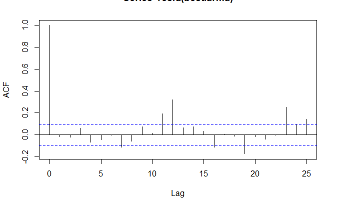

```r
best.order; acf(resid(best.arma))
```

predict

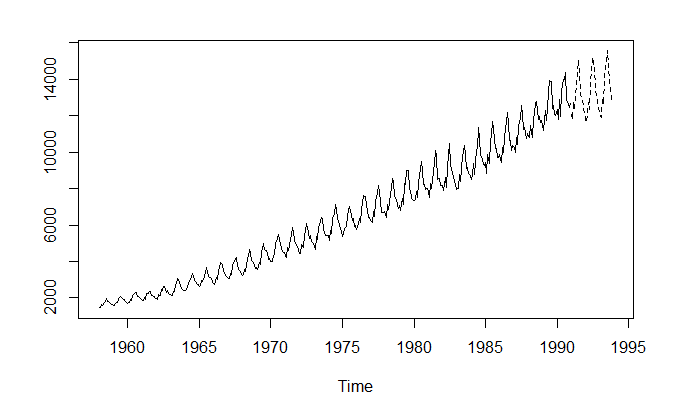

```r
new.time <- seq(length(elec.ts), length = 36)
new.data <- data.frame(time = new.time, Imth = rep(1:12, 3))
predictlm <- predict(elec.lm, newdata = new.data)
predictarma <- predict(best.arma, n.ahead = 36)
elec.pred <- ts(exp(predictlm + predictarma$pred), start = 1991, freq = 12)
ts.plot(cbind(elec.ts, elec.pred), lty = 1:2)
```

Not taking account of that annual seasonality completely…

## Non-Stationary Models

Many time series are non-stationary because of seasonal effects or trends.

Random walks, which characterize many types of series, are non-stationary but can be transformed to a stationary series by first order differencing. We can extend this random walk model by including autoregressive and moving average terms.

A note on terminology - as the differenced series needs to be aggregated or *‘integrated’* to recover the original series, this is an *autoregressive integrated moving average* or ARIMA model.

Series may also be non-stationary because the variance is serially correlated (known as *conditional heteroskedasticity*), which results in periods of high volatility (think of financial markets). Methods for dealing with this are using an autoregressive model for the variance - *autoregressive conditional heteroskedastic* or ARCH model. General version of this - GARCH.

#### Non-seasonal ARIMA models

- Differencing a series $\{x_t\}$ can remove trends, whether these trends are stochastic, as in a random walk, or deterministic, as in the case of a linear trend.
- In the case of a random walk, ${x_t} = {x_{t-1}} + {w_t}$, the first-order differenced series is white noise & so is stationary.
- With a linear trend with white noise errors, ${x_t} = a + bt + {w_t}$, then $\Delta{x_t} = {x_{t-1}} = b + {w_t} - {w_{t-1}}$, which is a stationary moving average process rather than white noise.

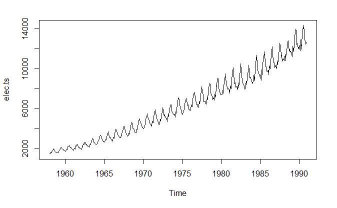

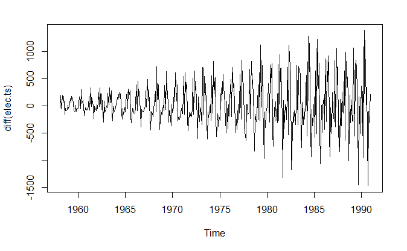

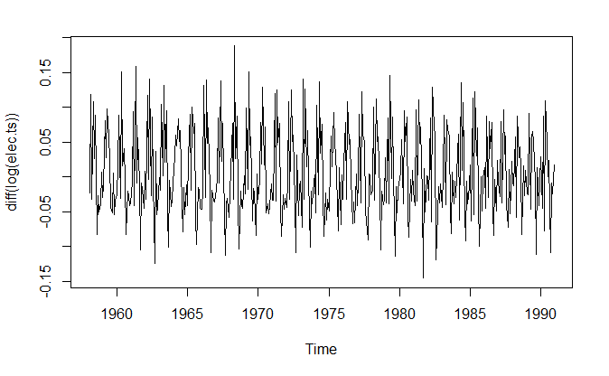

```r
url <- "https://raw.githubusercontent.com/dallascard/Introductory_Time_Series_with_R_datasets/master/cbe.dat"
cbe <- read.table(url, header = T)
elec.ts <- ts(cbe[, 3], start = 1958, freq = 12)
# layout(c(1, 1, 2, 3))
plot(elec.ts); plot(diff(elec.ts)); plot(diff(log(elec.ts)))
```

Note on the `diff` function:

- Change the `lag` argument to adjust which lag to use. Default is unity but `diff(x, lag = 12)` will remove both a linear trend adn additive seasonal effects in a monthly series.
- `differences` can allow for $n^{th}$ order differencing and can avoid repeated calls. Second-order differencing may sometimes successfully reduce a series with an underlying curve trend to white noise.

```r
diff(1:10); diff(diff(1:10)); diff(1:10, d = 2)
```

```
[1] 1 1 1 1 1 1 1 1 1
[1] 0 0 0 0 0 0 0 0
[1] 0 0 0 0 0 0 0 0
```

##### Simulation and fitting

Data for the $ARIMA(p, d, q)$ model $x_t = 0.5x_{t-1} + x_{t-1} - 0.5x_{t-2} + w_t + 0.3w_{t-1}$ are simulated and the model fitted to the simulated series to recover the parameter estimates:

```r
set.seed(1) # make simulated random data repeatable
x <- w <- rnorm(1000)
for(i in 3:1000) x[i] <- 0.5 * x[i - 1] + x[i - 1] - 0.5 * x[i - 2] + w[i] + 0.3 * w[i - 1]
arima(x = x, order = c(1, 1, 1))
```

```
Call:
arima(x = x, order = c(1, 1, 1))

Coefficients:
         ar1     ma1
      0.4235  0.3308
s.e.  0.0433  0.0450

sigma^2 estimated as 1.067:  log likelihood = -1450.13,  aic = 2906.26
```

Writing it like this can help you ensure you really understand what you’re doing. Alternatively, you could make your life easier and use `arima.sim`

#### IMA(1, 1) model fitted to the beer production series

```r
beer.ts <- ts(cbe[, 2], start = 1958, freq = 12)
beer.ima <- arima(beer.ts, order = c(0, 1, 1))
beer.ima
```

```
Call:
arima(x = beer.ts, order = c(0, 1, 1))

Coefficients:
          ma1
      -0.3334
s.e.   0.0558

sigma^2 estimated as 360.4:  log likelihood = -1723.27,  aic = 3450.53
```

From this output the fitted model is $x_t = x_{t-1} + w_t - 0.33w_{t-1}$.

Use the `predict` function with `n.ahead` set to the number of values in the future you want to predict.

```r
beer.1991 <- predict(beer.ima, n.ahead = 12); beer.1991
```

```
$pred
          Jan      Feb      Mar      Apr      May      Jun      Jul      Aug
1991 197.1177 197.1177 197.1177 197.1177 197.1177 197.1177 197.1177 197.1177
          Sep      Oct      Nov      Dec
1991 197.1177 197.1177 197.1177 197.1177

$se
          Jan      Feb      Mar      Apr      May      Jun      Jul      Aug
1991 18.98432 22.81613 26.09113 28.99859 31.64000 34.07727 36.35150 38.49160
          Sep      Oct      Nov      Dec
1991 40.51881 42.44933 44.29579 46.06830
```

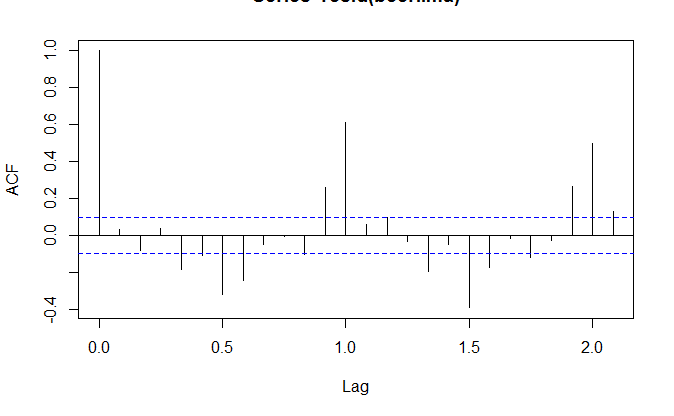

```r
acf(resid(beer.ima))
```

### Seasonal ARIMA models

A seasonal ARIMA model uses differencing at a lag equal to the number of seasons $(s)$ to remove the additive seasonal effects. As with lag 1 differencing to remove a trend, the lag $s$ differencing introduces a moving average term.

```r
AIC(arima(log(elec.ts), order = c(1, 1, 0), seas = list(order = c(1, 0, 0), 12)))
```

```
[1] -1764.741
```

```r
AIC(arima(log(elec.ts), order = c(0, 1, 1), seas = list(order = c(0, 0, 1), 12)))
```

```
[1] -1361.586
```

Can check by trial-and-error but can write a simple function to check…

To avoid over parametrisation, the *consistent* Akaike Information Criteria (CAIC; see Bozdogan, 1987) can be used in model selection.

```r
get.best.arima <- function(x.ts, maxord = c(1, 1, 1, 1, 1, 1)) {
  best.aic <- 1e8
  n <- length(x.ts)
  for(p in 0:maxord[1]) for(d in 0:maxord[2]) for(q in 0:maxord[3]) for(P in 0:maxord[4]) for(D in 0:maxord[5]) for(Q in 0:maxord[6])
  {
    fit <- arima(x.ts, order = c(p, d, q),
                 seas = list(order = c(P, D, Q),
                             frequency(x.ts)), method = "CSS")
    fit.aic <- -2 * fit$loglik + (log(n) + 1) * length(fit$coef)
    if(fit.aic < best.aic) {
      best.aic <- fit.aic
      best.fit <- fit
      best.model <- c(p, d, q, P, D, Q)
    }
  }
  list(best.aic, best.fit, best.model)
}
best.arima.elec <- get.best.arima(log(elec.ts), maxord = c(2, 2, 2, 2, 2, 2))
```

```
possible convergence problem: optim gave code = 1possible convergence problem: optim gave code = 1possible convergence problem: optim gave code = 1
```

```r
best.fit.elec <- best.arima.elec[[2]]
best.arima.elec[[3]]
```

```
[1] 0 1 1 2 0 2
```

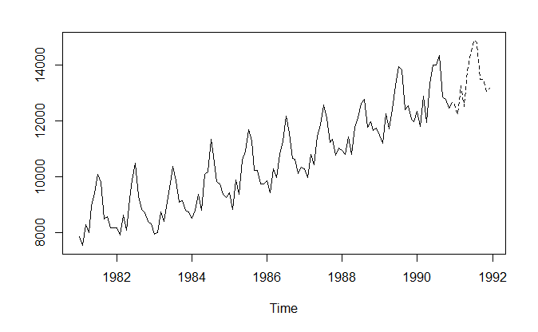

```r
ts.plot(cbind(window(elec.ts, start = 1981), exp(predict(best.fit.elec, 12)$pred)), lty = 1:2)
```

Best fitting model using terms up to second order is $ARIMA(0, 1, 1)(2, 0, 2). Higher-order terms could be tried but likely unnecessary since the residuals are approximately equal to white noise…

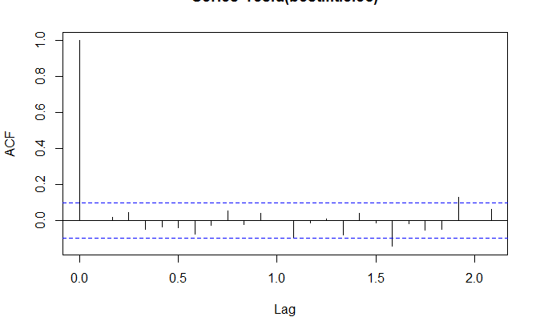

```r
acf(resid(best.fit.elec))
```

### ARCH Models

Data is daily returns of S&P500 in 1990s

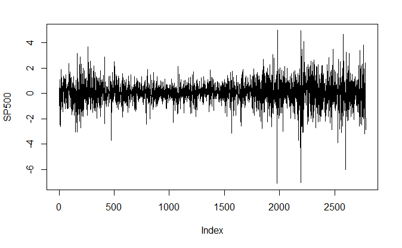

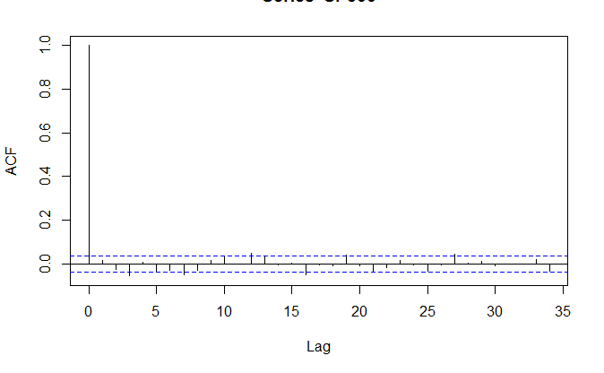

```r
require(MASS)
data("SP500")
plot(SP500, type = "l"); acf(SP500)
```

Looks pretty stationary - but variance appears to be correlated. When a variance is not constant in time but changes in a regular way, the series is called *heteroskedastic*. If a series exihibits periods of increased variance, so the variance is correlated in time (as observed here), the series exhibits volatility and is called *conditional heterskedastic*.

Note the correlogram does not look significantly different from white noise. However, the series is non-stationary since the variance is different at different times. Volatility can be detected by looking at a correlogram of the squared values since the squared values are equivalent to the variance (provided adjusted to have a mean of zero).

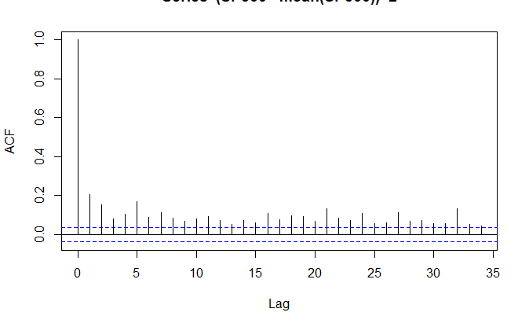

```r
acf((SP500 - mean(SP500))^2)
```

Here we can see there is evidence of serial correlation in the squared values, so there is evidence of conditional heteroskedastic behavior (volatility).

##### Modeling volatility: Definition of the ARCH model

Model must allow for conditional changes in the variance. One approach is to use an autoregressive model for the variance process.

A series $\{\epsilon_t\}$ is first order autoregressive conditional heteroskedastic, denoted $ARCH(1)$, if

$$\epsilon_t = {w_t} \sqrt{{\alpha_0} + {\alpha_1}{\epsilon^2_{t-1}}}$$
where $\{w_t\}$ is white noise with zero mean and unit variance and $\alpha_0$ and $\alpha_1$ are model parameters.

#### Extensions and GARCH models

First order $ARCH$ models can be extended to a $p$th-order process by including higher lags. A $GARCH$ (generalized) model can be fitted using the `garch` function in the `tseries` library.

#### Simulation and fitted GARCH model

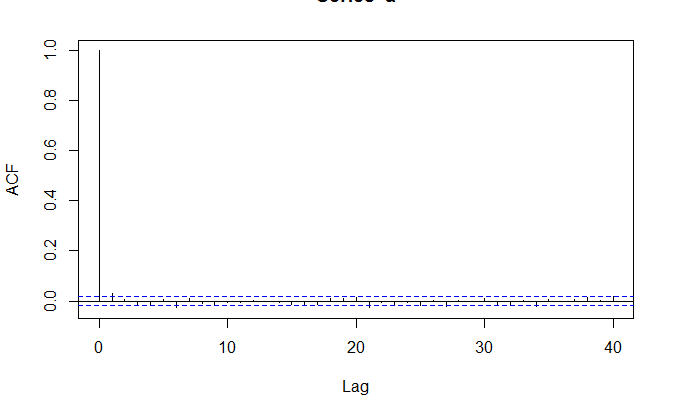

```r
set.seed(1)
alpha0 <- 0.1
alpha1 <- 0.4
beta1 <- 0.2
w <- rnorm(10000)
a <- h <- rep(0, 10000)
for(i in 2:10000) {
  h[i] <- alpha0 + alpha1 * (a[i - 1]^2) + beta1 * h[i - 1]
  a[i] <- w[i] * sqrt(h[i])
}
acf(a)
```

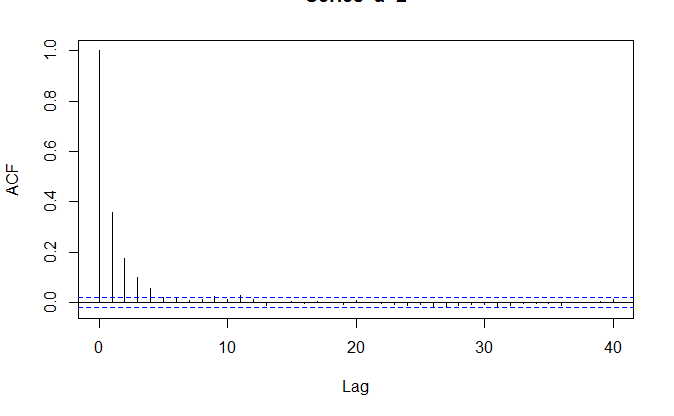

```r
acf(a^2)
```

Note uncorrelated values but correlated squared values.

Default for `garch` model is $GARCH(1, 1)$ but higher-order can be specified with `order = c(p, q)`

```r
require(tseries)
a.garch <- garch(a, grad = "numerical", trace = F)
confint(a.garch)
```

```
       2.5 %    97.5 %
a0 0.0882393 0.1092903
a1 0.3307897 0.4023932
b1 0.1928344 0.2954660
```

- `trace = F` suppresses output
- `grad = "numerical"` is slightly more robust than default

#### Fit to S&P 500

If $GARCH$ model is suitable the residual series should appear to be a realization of white noise with mean 0 and unit variance. In the case of $GARCH(1, 1)$:

$$\hat{h}_t = \hat{\alpha}_0 + \hat{\alpha}_1{\epsilon^2_{t-1}} + \hat{\beta}_1\hat{h}_{t-1}$$

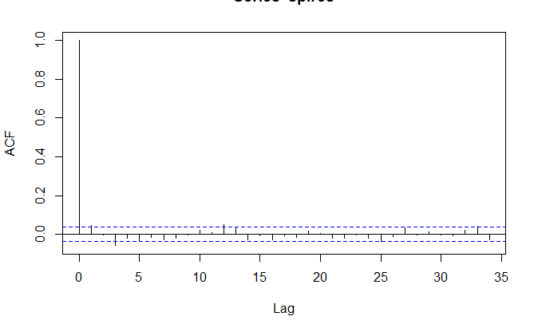

```r
sp.garch <- garch(SP500, trace = F)
sp.res <- sp.garch$res[-1]
acf(sp.res)
```

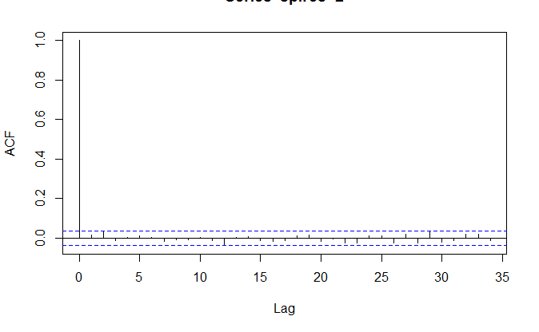

```r
acf(sp.res^2)
```

Both residual and squared residual behave like white noise.

##### Volatility in climate series

```r
url <- "https://raw.githubusercontent.com/dallascard/Introductory_Time_Series_with_R_datasets/master/stemp.dat"
stemp <- scan(url)
```

```
Read 1896 items
```

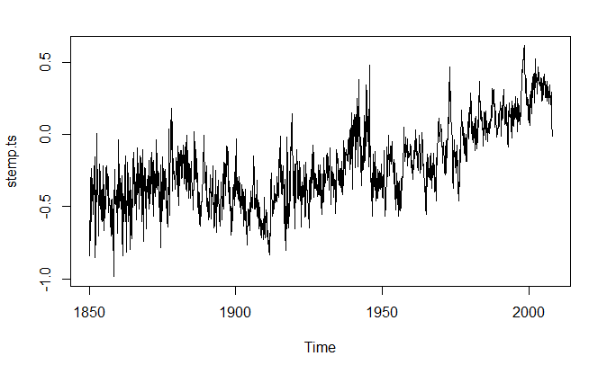

```r
stemp.ts <- ts(stemp, start = 1850, freq = 12)
plot(stemp.ts)
```

```r
stemp.best <- get.best.arima(stemp.ts, maxord = rep(2, 6))
```

[output not shown]

```r
stemp.best[[3]]
```

```
[1] 1 1 2 2 0 1
```

```r
stemp.arima <- arima(stemp.ts, order = c(1, 1, 2), seas = list(order = c(2, 0, 1), 12))
t(confint(stemp.arima))
```

```
             ar1       ma1       ma2      sar1        sar2       sma1
2.5 %  0.8317386 -1.447401 0.3256697 0.8576773 -0.02501929 -0.9690566
97.5 % 0.9127950 -1.312552 0.4530477 1.0041425  0.07413469 -0.8507002
```

Second seasonal AR component is not significantly different from zero, and therefore, the model is refitted leaving this component out:

```r
stemp.arima <- arima(stemp.ts, order = c(1, 1, 2), seas = list(order = c(1, 0, 1), 12))
t(confint(stemp.arima))
```

```
             ar1       ma1       ma2      sar1       sma1
2.5 %  0.8304009 -1.445057 0.3242735 0.9243494 -0.9694896
97.5 % 0.9108113 -1.311247 0.4509004 0.9956639 -0.8679222
```

Check fit with correlogram of residuals and volatility, correlogram of squared residuals:

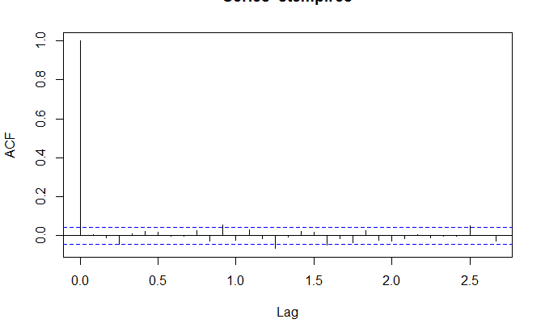

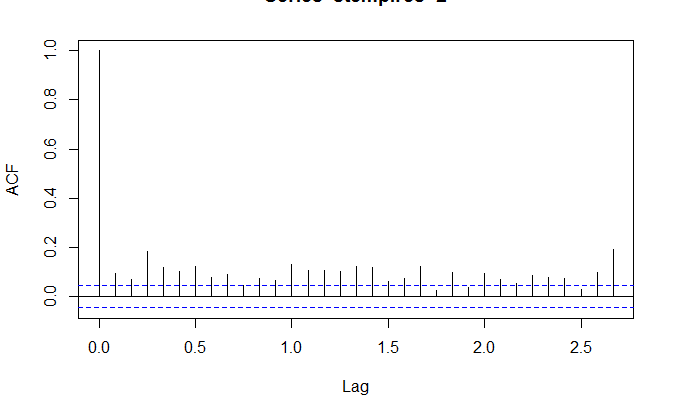

```r
stemp.res <- resid(stemp.arima)
acf(stemp.res); acf(stemp.res^2)
```

Similar to what we’ve seen before, squared residuals show evidence of volatility. To solve, a $GARCH$ model is fitted to the residuals:

```r
stemp.garch <- garch(stemp.res, trace = F)
t(confint(stemp.garch))
```

```
                 a0         a1        b1
2.5 %  1.064206e-05 0.03299211 0.9249312
97.5 % 1.485815e-04 0.06525721 0.9630785
```

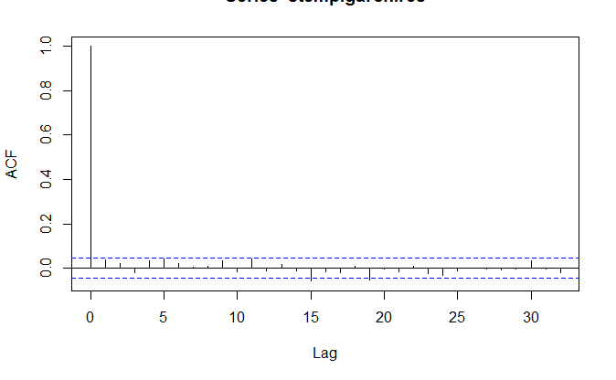

```r
stemp.garch.res <- resid(stemp.garch)[-1]
acf(stemp.garch.res)
```

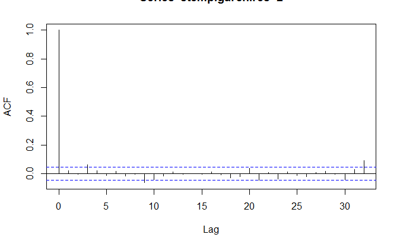

```r
acf(stemp.garch.res^2)
```

##### GARCH in forecasts and simulation

If a $GARCH$ model is fitted to the residual errors of a fitted time series model, it will not influence the *average* prediction at some point in time since the mean of the residual erros is zero. A fitted $GARCH$ model will affect the variance of simulated predicted values and thus result in periods of changing variance or volatility in simulated series.

Using these techniques to simulate studies in areas such as insurance, finance, and climatology is important because periods of high variability lead to untoward events and must be modeled in a realistic manner.

## Long-Memory Processes

Some time series exhibit marked correlations at high lags, and they are referred to as long-memory processes.

Long Short Term Memory Networks are a special kind of RNN which are especially good at handling long-memory processes. They have excellent potential for time series forecasting and have already been put to great use at Uber. R Studio has a package to interface to the keras API for this.

## Danger Zone

[figure not shown]

These are potentially exciting and useful but can also be very easy to misuse.

#### Facebook `Prophet` Package

Easy to use implementation for robust trend-based time series forecasts. Very easy to get a forecast. Very easy to get a bad forecast.

```r
require(prophet)
prophet.fcst <- prophet(data.frame(ds = seq(as.Date("1958-01-01"), as.Date("1990-12-01"), by = "m"), y = cbe[,3]))
```

```
Disabling weekly seasonality. Run prophet with `weekly.seasonality=TRUE` to override this.
```

```
Initial log joint probability = -3.03219
Optimization terminated normally:
  Convergence detected: absolute parameter change was below tolerance
```

```r
summary(prophet.fcst)
```

```
                        Length Class      Mode
growth                    1    -none-     character
changepoints             25    Date       numeric
n.changepoints            1    -none-     numeric
yearly.seasonality        1    -none-     logical
weekly.seasonality        1    -none-     logical
holidays                  0    -none-     NULL
seasonality.prior.scale   1    -none-     numeric
changepoint.prior.scale   1    -none-     numeric
holidays.prior.scale      1    -none-     numeric
mcmc.samples              1    -none-     numeric
interval.width            1    -none-     numeric
uncertainty.samples       1    -none-     numeric
start                     1    Date       numeric
y.scale                   1    -none-     numeric
t.scale                   1    -none-     numeric
changepoints.t           25    -none-     numeric
stan.fit                  0    -none-     NULL
params                    6    -none-     list
history                   4    data.frame list
history.dates           396    Date       numeric
```

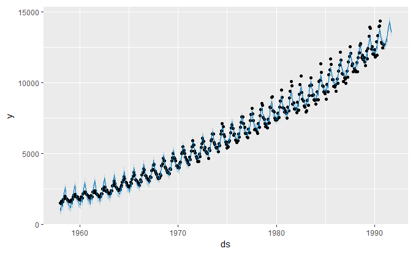

```r
future <- make_future_dataframe(prophet.fcst, periods = 10, freq = "month")
forecast <- predict(prophet.fcst, future)
plot(prophet.fcst, forecast)
```

#### Anomaly Detection

[This](https://github.com/twitter/AnomalyDetection) is a potentially very interesting time series analysis package produced by Twitter.

Depending on the use of your forecasts, close to real-time identification of unusual events can be a very important tool.

## Resources / Credits

These examples and ideas heavily draw on these two books - highly recommend buying and working your way through:

- [Introductory Time Series with R](https://goo.gl/FbSB1z)
- [Applied Predictive Modeling](http://www.springer.com/us/book/9781461468486)

#### Online Learning

- [Forecasting Using R on datacamp](https://www.datacamp.com/courses/forecasting-using-r)
- [xts cheat sheet](https://www.datacamp.com/community/blog/r-xts-cheat-sheet?utm_content=buffer0b542&utm_medium=social&utm_source=twitter.com&utm_campaign=buffer#gs.Sn0D9go)
- [time series analysis multi-part](http://www.business-science.io/timeseries-analysis/2017/08/30/tidy-timeseries-analysis-pt-4.html)

#### Books

- [Forecasting Principles & Practice](http://otexts.org/fpp2/)
- [A Little Book of R for Time Series](http://a-little-book-of-r-for-time-series.readthedocs.io/en/latest/)
- [Introductory Time Series with R](https://goo.gl/FbSB1z)
- [Applied Predictive Modeling](http://www.springer.com/us/book/9781461468486)

#### CRAN Task Views

- [Time Series](https://cran.r-project.org/web/views/TimeSeries.html)
- [Econometrics](https://cran.r-project.org/web/views/Econometrics.html)
- [Finance](https://cran.r-project.org/web/views/Finance.html)

#### Packages

- [lubridate](https://cran.r-project.org/web/packages/lubridate/lubridate.pdf)
- [xts](https://cran.r-project.org/web/packages/xts/xts.pdf)
- [zoo](https://cran.r-project.org/web/packages/zoo/zoo.pdf)
- [chron](https://cran.r-project.org/web/packages/chron/chron.pdf)
- [timeDate](https://cran.r-project.org/web/packages/timeDate/timeDate.pdf)
- [tSeries](https://cran.r-project.org/web/packages/tseries/tseries.pdf)
- [caret](https://cran.r-project.org/web/packages/caret/caret.pdf)
- [forecast](https://cran.r-project.org/web/packages/forecast/forecast.pdf)
- [prophet](https://cran.r-project.org/web/packages/prophet/prophet.pdf)

#### People

- [Rob J Hyndman](https://robjhyndman.com/)

```
 setting  value
 version  R version 3.4.1 (2017-06-30)
 system   x86_64, mingw32
 ui       RStudio (1.0.153)
 language (EN)
 collate  English_United States.1252
 tz       America/New_York
 date     2017-09-27
```

```
Packages -----------------------------------------------------------------------
```

[output not shown]

[output cut: 17 more lines]

[output not shown]